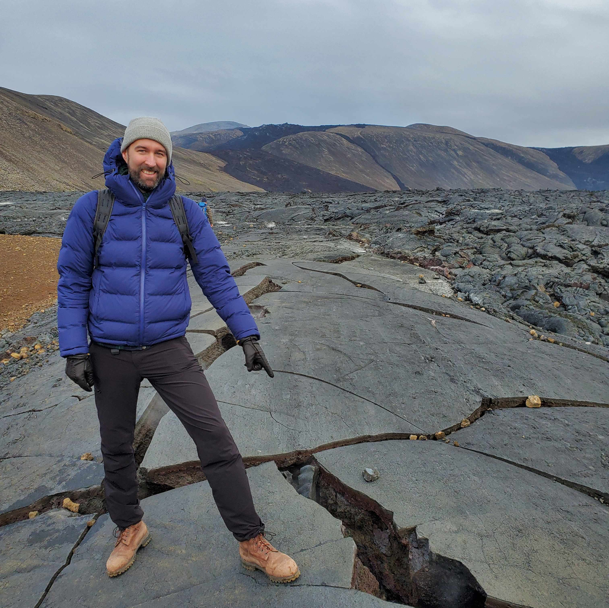

# Johannes Feldhege, M.Sc. B.A.

## Über mich

Als wissenschaftlicher Mitarbeiter am Uniklinikum Heidelberg habe ich von 2017-2022 mit Natural Language Processing Methoden Unterhaltungen zum Thema psychischer Gesundheit auf Reddit untersucht. In Praktika und in ehrenamtlicher Tätigkeit habe ich verschiedene Data Science Projekte mitgestaltet.

#### Kontakt:

Email: mail [at] johannesfeldhege.de

## Ausbildung

**Psychologie M.Sc.** | 2013-2016 | Universität Kassel

**Psychologie B.Sc.** | 2010-2013 | Universität Hamburg

**Soziologie und Sinologie B.A.** | 2007-2010 | Albert-Ludwigs-Universität Freiburg

**International Baccalaureate** | 2007 | Malvern College, United Kingdom

## Berufliche Erfahrung

**Data Scientist** | Asklepios proresearch, Hamburg | 09/2022-

**Wissenschaftlicher Mitarbeiter** | Forschungsstelle für Psychotherapie, Uniklinikum Heidelberg | 2016-2022

**Data Science Praktikant** | Eoda GmbH, Kassel | 2016

**R Tutor** | Universität Kassel | 2014-2015

**Studentische Hilfskraft** | Servicestelle Empirische Forschungsmethoden, Universität Hamburg | 2011–2013

## Data Science Kenntnisse

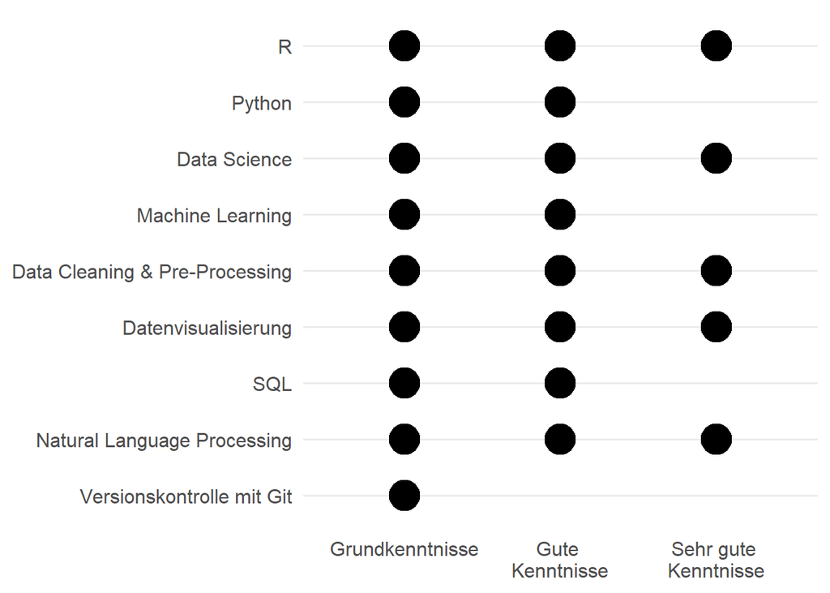

## Projekte

**redditoR**: Ein R Paket für Zugriffe auf die API des sozialen Netzwerks Reddit. [Github](https://github.com/jfeldhege/redditoR)

**Textanalyse von Call-Dokumentationen zur Erarbeitung von Herausforderungen und Erfolgen in vergangenen Projekten**: Ein Projekt mit projecttogether und CorrelAid.

**Die Platte unter der Lupe: Einflussfaktoren auf die Absatzzahlen einer Mannheimer Suppenküche**: Untersuchung der Absatzzahlen des Lokals Mannheimer Platte und deren saisonale und externe Einflussfaktoren. Ein Projekt mit der Mannheimer Platte und CorrelAid. [Projektbericht](http://dx.doi.org/10.31219/osf.io/3zsn6)

## Veröffentlichungen

**Feldhege J. M.**, Gulec H., Moessner M., Stieler C., van Stipelen J., Bauer S. *Stigmatization and attitudes toward eating disorders: a comparison between native German adolescents, Turkish immigrant adolescents in Germany, and native Turkish adolescents*. Journal of Mental Health (2022). doi: https://dx.doi.org/10.1080/09638237.2021.1979484

**Johannes Feldhege**, Markus Moessner, Stephanie Bauer. *Detrimental Effects of Online Pro–Eating Disorder Communities on Weight Loss and Desired Weight: Longitudinal Observational Study*. Journal of Medical Internet Research (2021). http://dx.doi.org/10.2196/27153

**Johannes Feldhege**, Markus Moessner, Markus Wolf, Stephanie Bauer. *Changes in Language Style and Topics in an Online Eating Disorder Community at the Beginning of the Global COVID-19 Pandemic: Observational Study*. Journal of Medical Internet Research (2021). http://dx.doi.org/10.2196/28346

Ali, K., Fassnacht, D. B., Farrer, L., Rieger, E., **Feldhege, J.**, Moessner, M., . . . Bauer, S. *What prevents young adults from seeking help? Barriers toward help-seeking for eating disorder symptomatology*. International Journal of Eating Disorders, (2020). https://dx.doi.org/10.1002/eat.23266

Wilhelm, M., **Feldhege, J.**, Bauer. S., & Moessner, M. *Einsatz internetbasierter Verlaufsmessung in der Psychotherapieforschung*. Psychotherapeut, (2020). https://doi.org/10.1007/s00278-020-00461-7

**Feldhege, J.**, Moessner, M., Stieler, C., van Stipelen, J., & Bauer, S. *Wissen und Einstellungen zu Essstörungen bei Jugendlichen mit türkischem Migrationshintergrund*. Psychotherapeut, (2019). https://doi.org/10.1007/s00278-018-0327-8

**Johannes Feldhege**, Markus Moessner, Stephanie Bauer. *Who says What? Content and Participation Characteristics in an Online Depression Community*. Journal of Affective Disorders (2019). http://dx.doi.org/10.1016/j.jad.2019.11.007

Markus Moessner, **Johannes Feldhege**, Markus Wolf, Stephanie Bauer. *Analyzing big data in social media: Text and network analyses of an eating disorder forum*. International Journal of Eating Disorders (2018). http://dx.doi.org/10.1002/eat.22878

Website mit postcards erstellt.